# Model Fit and Hyperpriors

Ben Weinstein

July 16, 2015

In the literature, there has been proposed model criteria for occupancy models using AUC as a measure of predicted presence and absence in Zipkin 2012

However, we are using a N-mixture model that estimates the abundance, not the presence/absence, and i don’t think there is an analogous solution.

It appears that dominant idea in the literature is pick some test statistic, and compare how well models do to minimize that test statistic relative to a null model of intercept alone.

The goal of this paper is to measure the impact of bill and corolla morphology on the frequency of interactions between hummingbirds and plants. The model can be written like this:

$Y_{i,j,k} \sim Binom(N_{i,j},detect_i)$ $N_{i,j} \sim Pois(\lambda_{i,j})$ $log(\lambda_{i,j})<-\alpha_i + \beta_i * abs(Bill_i - Corolla_i)$ $detect_i \sim U(0,1)$

# Problem Statement

The question becomes whether the alpha and beta parameters for each species should come from hierarchical distribution for all hummingbirds: **Priors**

$\alpha_i \sim N(intercept,\tau_{\alpha})$ $\beta_i \sim N(\gamma,\tau_{\beta})$

**Hyperpriors** $gamma \sim N(0.001,0.001)$ $intercept \sim N(0.001,0.001)$

$\tau_{\alpha} \sim Gamma(0.001,0.001)$ $\tau_\beta \sim Gamma(0.001,0.001)$

Or whether there should be fixed effects for species-level distributions:

**Priors**

$\alpha_i \sim N(0.001,0.001)$ $\beta_i \sim N(0.001,0.001)$

My concern is whether the borrowing strength of the grouping is overwhelming the effect size.

## Measuring Fit

Following the example from [Kery’s book](http://www.mbr-pwrc.usgs.gov/software/kerybook/) we use the discrepancy between the predicted posterior and the observed data as our measure of model fit.

# Prepare the data

Get the data in the correct form - not echoed.

```
## [1] "White-sided Flowerpiercer"
```

### Elevation ranges

Create a binary variable whether each observation was in a low elevation or high elevation transect. We have some species that just occur at the top of the gradient, and are not present in the sampling window of flowers at the low elevation.

Accounting for non-availability. We have to figure out which plants were sampled in which periods, and if it was sampled, the non-detections are 0 if it wasn’t the non-detections are NA. then remove all the Na’s.

```
##                 Hummingbird  Low        m High Index
## 1   Green-crowned Woodnymph 1359 1376.645 1390     1
## 2 Rufous-tailed Hummingbird 1368 1476.333 1380     1
## 3            Andean Emerald 1378 1386.261 1380     1
## 4      White-necked Jacobin 1368 1397.500 1422     1
## 5    Stripe-throated Hermit 1368 1440.887 1450     1
## 6    White-whiskered Hermit 1340 1412.391 1450     1
```

The final data structure, called indat, looks like this.

```
##     Bird Plant Time Yobs
## 145    1    22    1    0
## 150    6    22    1    0
## 153    9    22    1    0
## 154   10    22    1    0
## 156   12    22    1    1
## 385    1     8    2    0
```

# Hierarchical model

$Y_{i,j,k} \sim Binom(N_{i,j},detect_i)$ $N_{i,j} \sim Pois(\lambda_{i,j})$ $log(\lambda_{i,j})<-\alpha_i + \beta_i * abs(Bill_i - Corolla_i)$ $detect_i \sim U(0,1)$

**Priors**

$\alpha_i \sim N(intercept,\tau_{\alpha})$ $\beta_i \sim N(\gamma,\tau_{\beta})$

**Hyperpriors** $gamma \sim N(0.001,0.001)$ $intercept \sim N(0.001,0.001)$

$\tau_{\alpha} \sim Gamma(0.001,0.001)$ $\tau_\beta \sim Gamma(0.001,0.001)$

**Derived quantities**

$\sigma_{int} = \frac{1}{\tau_{\alpha}}^2$ $\sigma_{slope} = \frac{1}{\tau_{\beta}}^2$

```
##  [1]
##  [2] sink("Bayesian/NMixtureRagged.jags")
##  [3]
##  [4] cat("
##  [5]     model {
##  [6]
##  [7]   for (i in 1:Birds){
##  [8]     for (j in 1:Plants){
##  [9]       #Process Model
## [10]       log(lambda[i,j])<-alpha[i] + beta[i] * traitmatch[i,j]
## [11]
## [12]       #True state model
## [13]       N[i,j] ~ dpois(lambda[i,j])
## [14]       }
## [15]     }
```

[output cut: 36 more lines]

```
##    Graph Size: 39940
##
```

### Assess Convergence

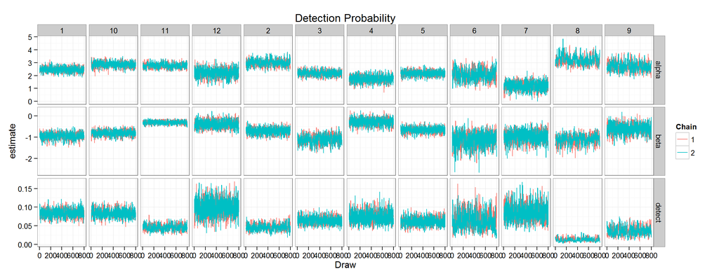

### Hierarcichal Posteriors

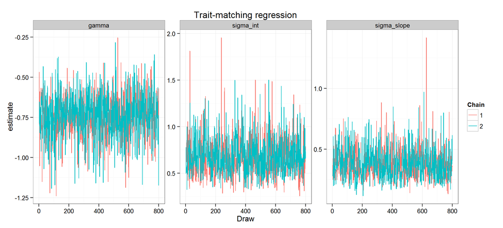

# Fixed species effects

$Y_{i,j,k} \sim Binom(N_{i,j},detect_i)$ $N_{i,j} \sim Pois(\lambda_{i,j})$ $log(\lambda_{i,j})<-\alpha_i + \beta_i * abs(Bill_i - Corolla_i)$ $detect_i \sim U(0,1)$

**Priors**

$\alpha_i \sim N(0.001,0.001)$ $\beta_i \sim N(0.001,0.001)$

```
##  [1]
##  [2] sink("Bayesian/NMixtureRaggedFixed.jags")
##  [3]
##  [4] cat("
##  [5]     model {
##  [6]
##  [7]   for (i in 1:Birds){
##  [8]     for (j in 1:Plants){
##  [9]       #Process Model
## [10]       log(lambda[i,j])<-alpha[i] + beta[i] * traitmatch[i,j]
## [11]
## [12]       #True state model
## [13]       N[i,j] ~ dpois(lambda[i,j])
## [14]       }
## [15]     }
```

[output cut: 27 more lines]

```
##    Graph Size: 39931
##
```

### Assess Convergence

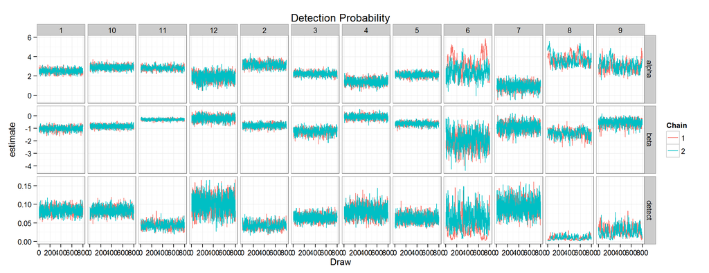

### Posteriors

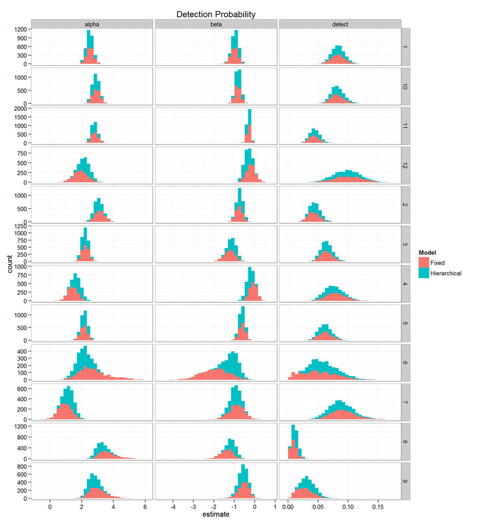

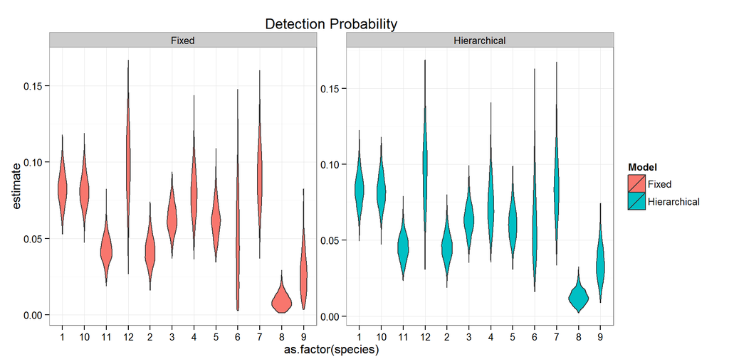

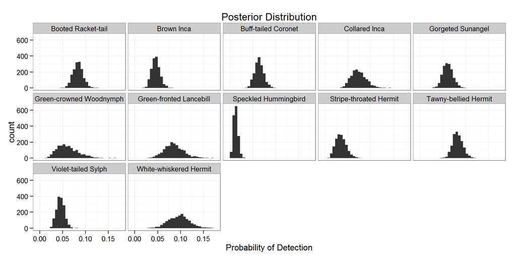

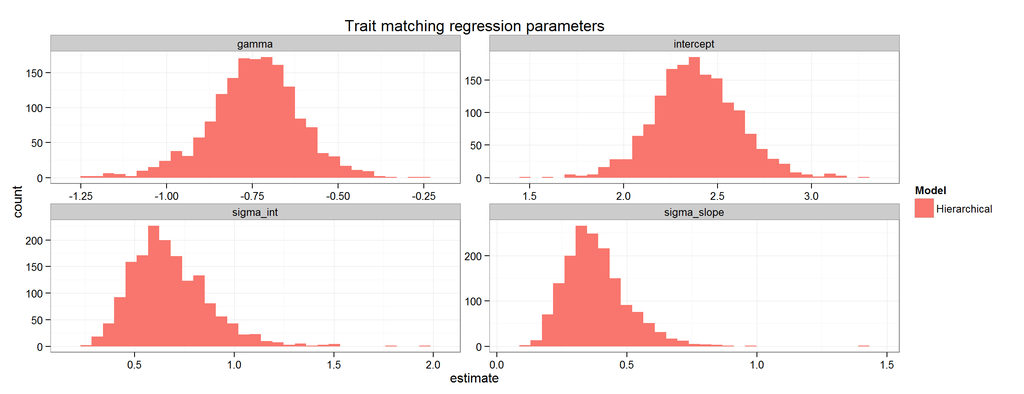

### Species Predictions

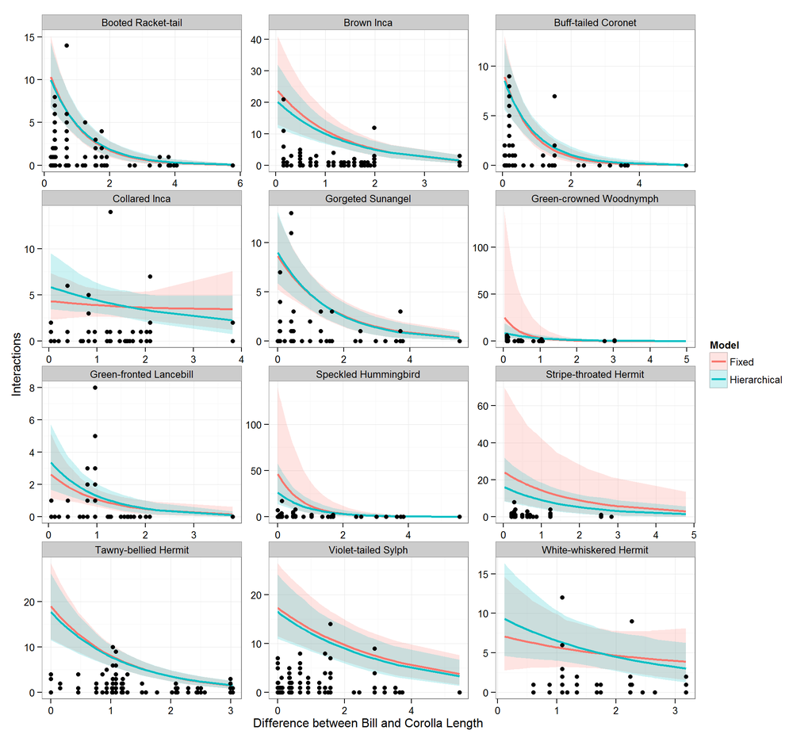

### Discrepancy

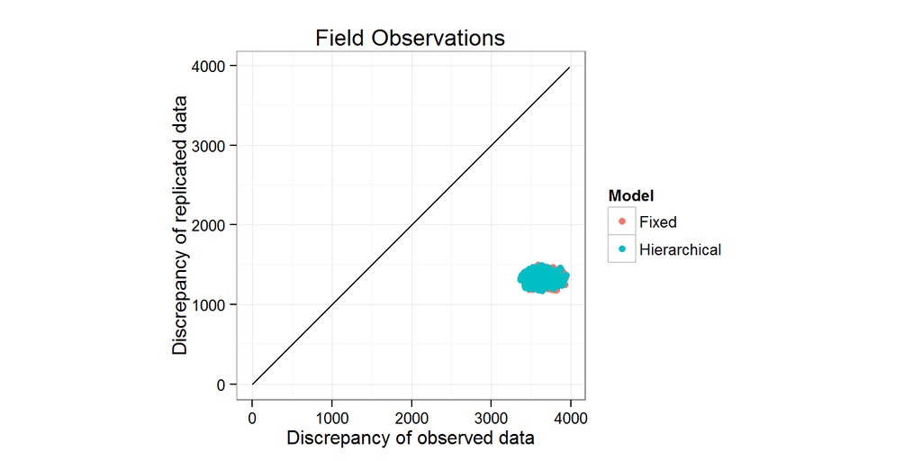